# Spotify audio features project

Weronika Motkowska

2023-01-16

# Spotify data

The idea for this project has been inspired by paper by Sciandra, Mariangela; Spera, Irene; 2020/01/01; “A Model Based Approach to Spotify Data Analysis: A Beta GLMM”; 10.2139/ssrn.3557124; SSRN Electronic Journal.

The aim of this paper is to investigate if audio features from Spotify can be considered as determinants of the stream popularity of songs. The data is available through Spotify Developers API and library “spotifyr” gives clean code for requesting.

In this project the extracted data will consider different artist from 3 genres and the explained variable will be popularity which can have values from 0 to 100. However, the values are distributed the way the boundary values are not really possible, so the explained variable can be considered as continuous in this project.

First, let us load the libraries and data. For privacy reasons the dataset obtained from API will be loaded. However, the commented out code can be used for reproduction of requesting the data.

```r
library(rvest)
library(tidyverse)
library(spotifyr)
library(knitr)
library(ggplot2)
library(caret)
library(tree)
library(rpart)
library(rpart.plot)
```

```r
# Sys.setenv(SPOTIFY_CLIENT_ID = "***")
# Sys.setenv(SPOTIFY_CLIENT_SECRET = "***")
# access_token <- get_spotify_access_token()
```

```r
get_audio_features <- function(artist_name, artist_id, genre){

  artist <- search_spotify(artist_name, type = "artist", market = "US", limit = 1)
  top <- get_artist_top_tracks(artist_id,
                               market = "US") %>%
    select(name, id, popularity)

  top.features <- data.frame()
  for (id in top$id){
    top.features <- get_track_audio_features(id) %>%
      bind_rows(top.features)
  }

  top <- top %>%
    left_join(top.features) %>%
    select(-c(15:18, 20)) %>%
    mutate(followers.total = artist$followers.total) %>%
    mutate(genre = genre)

  rm(artist,
     top.features)

  return(top)
}
```

```r
# artists <- get_genre_artists(genre = "pop", market = "US", limit = 20) %>%
#              mutate(genre = "pop") %>%
#            bind_rows(get_genre_artists(genre = "rap", market = "US", limit = 20) %>% mutate(genre = "rap")) %>%
#            bind_rows(get_genre_artists(genre = "rock", market = "US", limit = 20) %>% mutate(genre = "rock")) %>%
#            select(name, id, genre)
```

```r
# artist.data <- data.frame()
# for (i in 1:nrow(artists)){
#   artist_name <- artists[i, 1][[1]]
#   artist_id   <- artists[i, 2][[1]]
#   genre <- artists[i, 3][[1]]
#   artist.data <- bind_rows(artist.data, get_audio_features(artist_name, artist_id, genre))
# }
#
# save(artist.data, file = "data")
```

From the available data We have chosen 20 top artists from each genre and used 10 top songs from each one of them. For every song we obtain its audio features which characteristics can be understood from variable names. The table below shows 17 variables. Name, id and genre will not be used in analysis. Total followers is an indicator of artists’ popularity.

```r
load("data")
str(artist.data)
```

```
## 'data.frame':    600 obs. of  17 variables:
##  $ name            : chr  "Anti-Hero" "Lavender Haze" "Midnight Rain" "Don’t Blame Me" ...
##  $ id              : chr  "0V3wPSX9ygBnCm8psDIegu" "5jQI2r1RdgtuT8S3iG8zFC" "3rWDp9tBPQR9z6U5YyRSK4" "1R0a2iXumgCiFb7HEZ7gUE" ...
##  $ popularity      : int  97 89 89 88 87 78 86 86 85 85 ...
##  $ danceability    : num  0.637 0.733 0.643 0.615 0.663 0.753 0.696 0.696 0.637 0.642 ...
##  $ energy          : num  0.643 0.436 0.363 0.534 0.319 0.678 0.396 0.559 0.398 0.62 ...
##  $ key             : int  4 10 0 9 9 5 2 7 7 8 ...
##  $ loudness        : num  -6.57 -10.49 -11.74 -6.72 -13.48 ...
##  $ mode            : int  1 1 1 0 1 1 1 1 1 1 ...
##  $ speechiness     : num  0.0519 0.08 0.0767 0.0386 0.0375 0.0644 0.0656 0.0693 0.0564 0.0666 ...
##  $ acousticness    : num  0.13 0.258 0.69 0.106 0.69 0.085 0.401 0.0618 0.0573 0.0734 ...
##  $ instrumentalness: num  1.80e-06 5.73e-04 5.17e-05 1.76e-05 9.93e-04 1.64e-06 5.20e-06 5.58e-05 1.03e-06 0.00 ...
##  $ liveness        : num  0.142 0.157 0.115 0.0607 0.117 0.13 0.125 0.0887 0.101 0.483 ...
##  $ valence         : num  0.533 0.0976 0.23 0.193 0.193 0.583 0.38 0.433 0.0374 0.0969 ...
##  $ tempo           : num  97 97 140 136 110 ...
##  $ duration_ms     : int  200690 202396 174783 236413 256124 231827 194207 194166 218271 204852 ...
##  $ followers.total : int  66037368 66037368 66037368 66037368 66037368 66037368 66037368 66037368 66037368 66037368 ...
##  $ genre           : chr  "pop" "pop" "pop" "pop" ...
```

The song popularity score is similarly distributed, with “rock” being a little bit uncool compared to other genres. The top songs in our catalog are around 80 score in popularity.

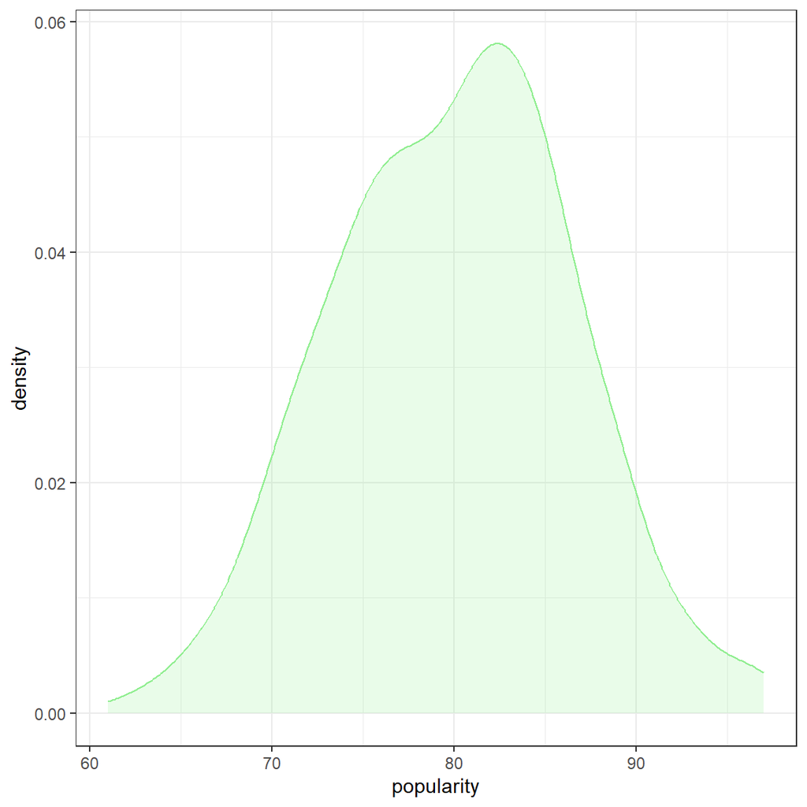

```r
ggplot(artist.data, aes(popularity)) +
  geom_density(alpha = 0.2, fill = "lightgreen", colour = "lightgreen") +
    theme_bw()
```

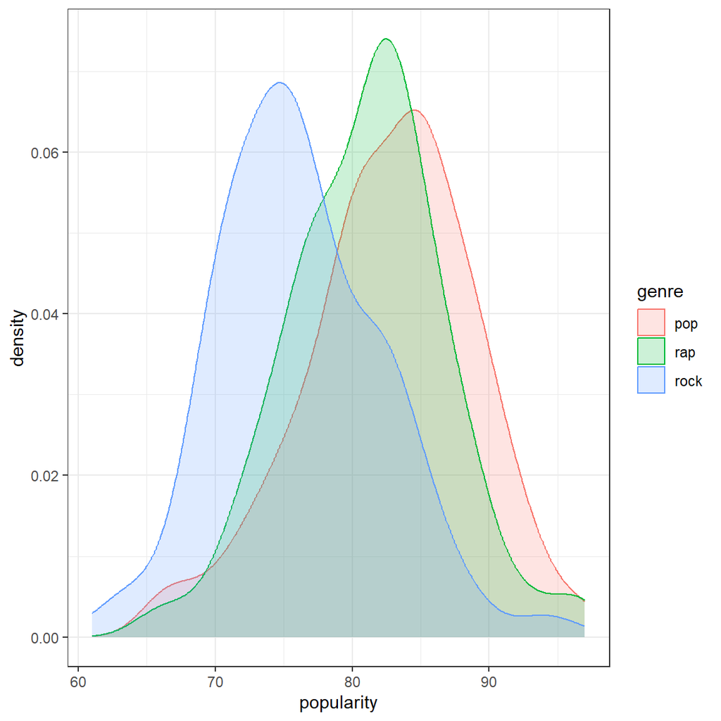

```r
ggplot(artist.data, aes(popularity, fill = genre, colour = genre)) +
  geom_density(alpha = 0.2) +
    theme_bw()
```

```r
artist.data %>%
    select(popularity) %>%
    summary()
```

```
##    popularity
##  Min.   :61.00
##  1st Qu.:75.00
##  Median :80.00
##  Mean   :79.99
##  3rd Qu.:85.00
##  Max.   :97.00
```

# Regression trees and linear model

### From simple linear model on whole dataset we can explore some characteristics.

```r
options(scipen = 8)
data <- artist.data %>% select(-c(name, id, genre))
formula <- popularity ~ .
model.lm <- lm(formula, data)
summary(model.lm)
```

```
##
## Call:
## lm(formula = formula, data = data)
##
## Residuals:
##      Min       1Q   Median       3Q      Max
## -22.0470  -3.5798   0.1036   3.8378  17.9579
##
## Coefficients:
##                        Estimate     Std. Error t value Pr(>|t|)
## (Intercept)      86.16376406036  3.28745075126  26.210  < 2e-16 ***
## danceability      4.87572157320  1.86880692381   2.609  0.00931 **
## energy           -7.67972952758  2.45141144429  -3.133  0.00182 **
## key              -0.00145704558  0.07007320354  -0.021  0.98342
## loudness          0.56222870750  0.13633407336   4.124 4.26e-05 ***
## mode             -0.33663254389  0.52323544781  -0.643  0.52024
## speechiness      -0.75520957589  2.23652746003  -0.338  0.73573
## acousticness      0.90042322369  1.27959945730   0.704  0.48191
## instrumentalness -0.44617302155  2.46953889426  -0.181  0.85669
## liveness          0.29728022968  1.86916124796   0.159  0.87369
## valence          -3.17956067543  1.25778038188  -2.528  0.01174 *
## tempo             0.00699228270  0.00887929550   0.787  0.43132
## duration_ms      -0.00000927368  0.00000438453  -2.115  0.03484 *
## followers.total   0.00000008077  0.00000001078   7.490 2.54e-13 ***
## ---
## Signif. codes:  0 '***' 0.001 '**' 0.01 '*' 0.05 '.' 0.1 ' ' 1
##
## Residual standard error: 5.998 on 586 degrees of freedom
## Multiple R-squared:  0.1865, Adjusted R-squared:  0.1684
## F-statistic: 10.33 on 13 and 586 DF,  p-value: < 2.2e-16
```

```r
formula <- popularity ~ danceability + energy + loudness + valence + duration_ms + followers.total
model.lm <- lm(formula, data)
summary(model.lm)
```

```
##
## Call:
## lm(formula = formula, data = data)
##
## Residuals:
##      Min       1Q   Median       3Q      Max
## -22.2168  -3.5322   0.1819   3.8341  18.0459
##
## Coefficients:
##                       Estimate     Std. Error t value Pr(>|t|)
## (Intercept)     87.58160587673  2.74746300371  31.877  < 2e-16 ***
## danceability     4.45448507779  1.70657286440   2.610 0.009278 **
## energy          -8.22737555951  2.24619384176  -3.663 0.000272 ***
## loudness         0.55948491978  0.13310614247   4.203 3.04e-05 ***
## valence         -3.03485530918  1.21743119358  -2.493 0.012944 *
## duration_ms     -0.00000984161  0.00000429579  -2.291 0.022314 *
## followers.total  0.00000008128  0.00000001053   7.716 5.11e-14 ***
## ---
## Signif. codes:  0 '***' 0.001 '**' 0.01 '*' 0.05 '.' 0.1 ' ' 1
##
## Residual standard error: 5.969 on 593 degrees of freedom
## Multiple R-squared:  0.1845, Adjusted R-squared:  0.1762
## F-statistic: 22.35 on 6 and 593 DF,  p-value: < 2.2e-16
```

Danceability and loudness have significant positive impact on popularity. The hypothesis is that the song is more popular if it is catchy and suitable for dancing on TikTok.

The simple analysis shows that popularity of the artist significantly influences popularity score of the song. The longer the song the less popular it is, with duration having negative sign next to it.

What is interesting is that the song does not have to be energetic to be popular and danced to. The positiveness (valence) is also considered not popular.

Other charasteristics, which are more technical, seem not to have much of importance.

### Let us now try regression trees.

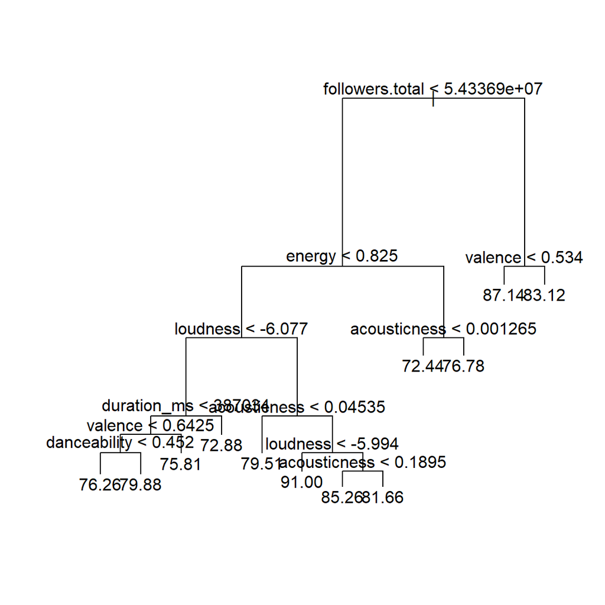

```r
set.seed(22061999)
data <- artist.data %>% select(-c(name, id, genre))
formula <- popularity ~ .
training_obs <- createDataPartition(data$popularity,
                                    p = 0.7,
                                    list = FALSE)
data.train <- data[training_obs,]
data.test  <- data[-training_obs,]

tree1 <- tree(formula, data.train, minsize = 50)
plot(tree1); text(tree1, pretty = 0)
```

The first look at the regression tree with limitation of minimum 50 items in each node gives some interesting insights. Loudness and acousticness seem to be variables that enable to tell apart songs popularity between 80 and 90 when the artist is not as popular as the top ones. You can also spot that the more valence the less popular song is.

Next we will try to clean the regression tree and find an optimal number of nodes. To do this I will use cross-validation methods for choosing tree complexity.

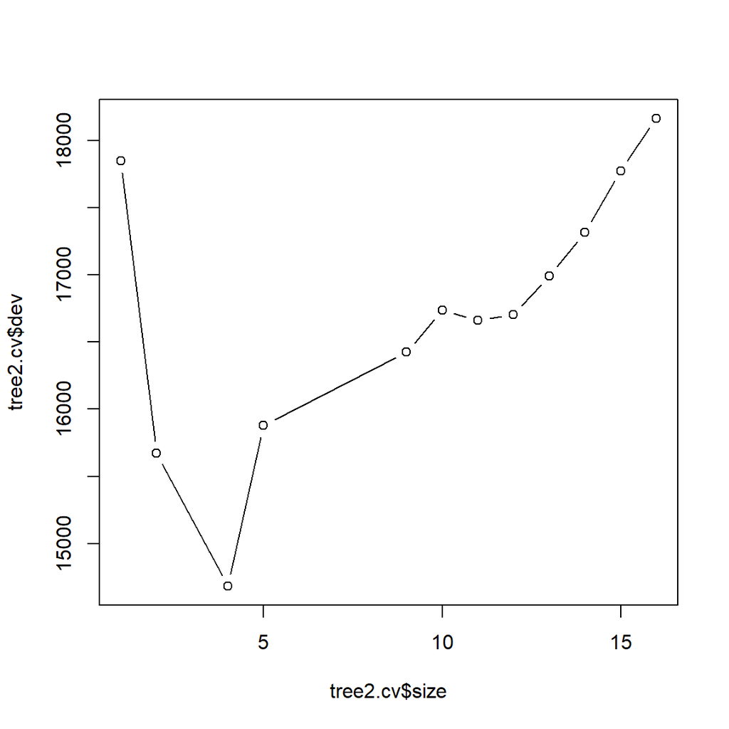

```r
set.seed(22061999)
tree2 <- tree(formula, data.train)
tree2.cv <- cv.tree(tree2, K = 15)
plot(tree2.cv$size, tree2.cv$dev, type = 'b')
```

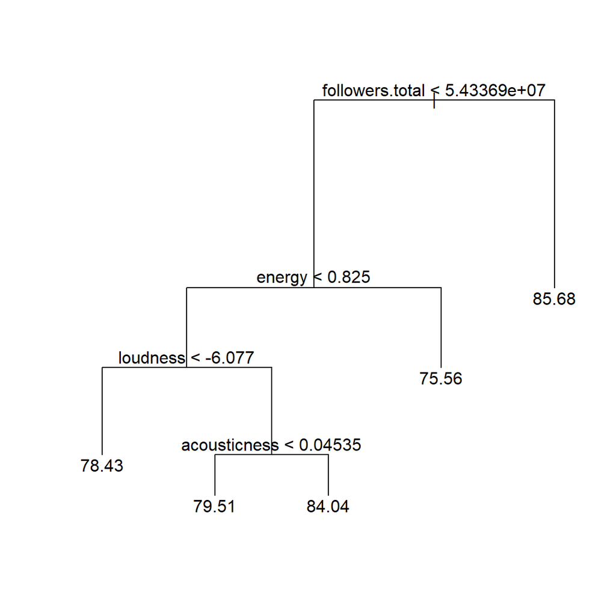

```r
tree3 <- prune.tree(tree2, best = 5)
plot(tree3); text(tree3, pretty = 0)
```

```r
tree4 <- prune.tree(tree2, best = 4)
# plot(tree4); text(tree4, pretty = 0)
```

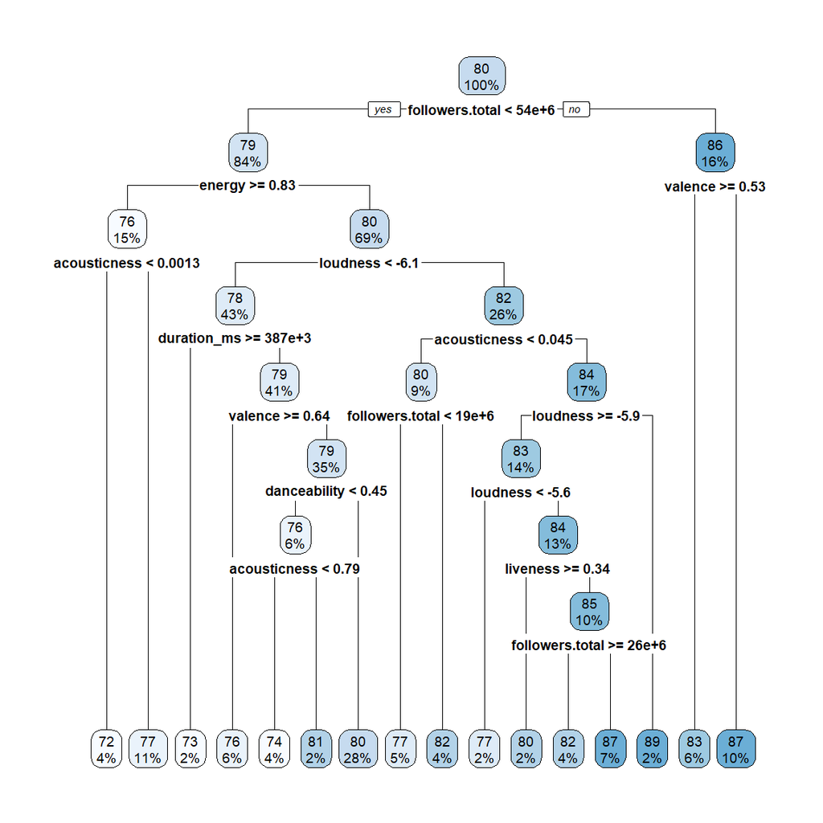

```r
set.seed(22061999)
tree5 <- rpart(formula, data.train, method = "anova")
rpart.plot(tree5)
```

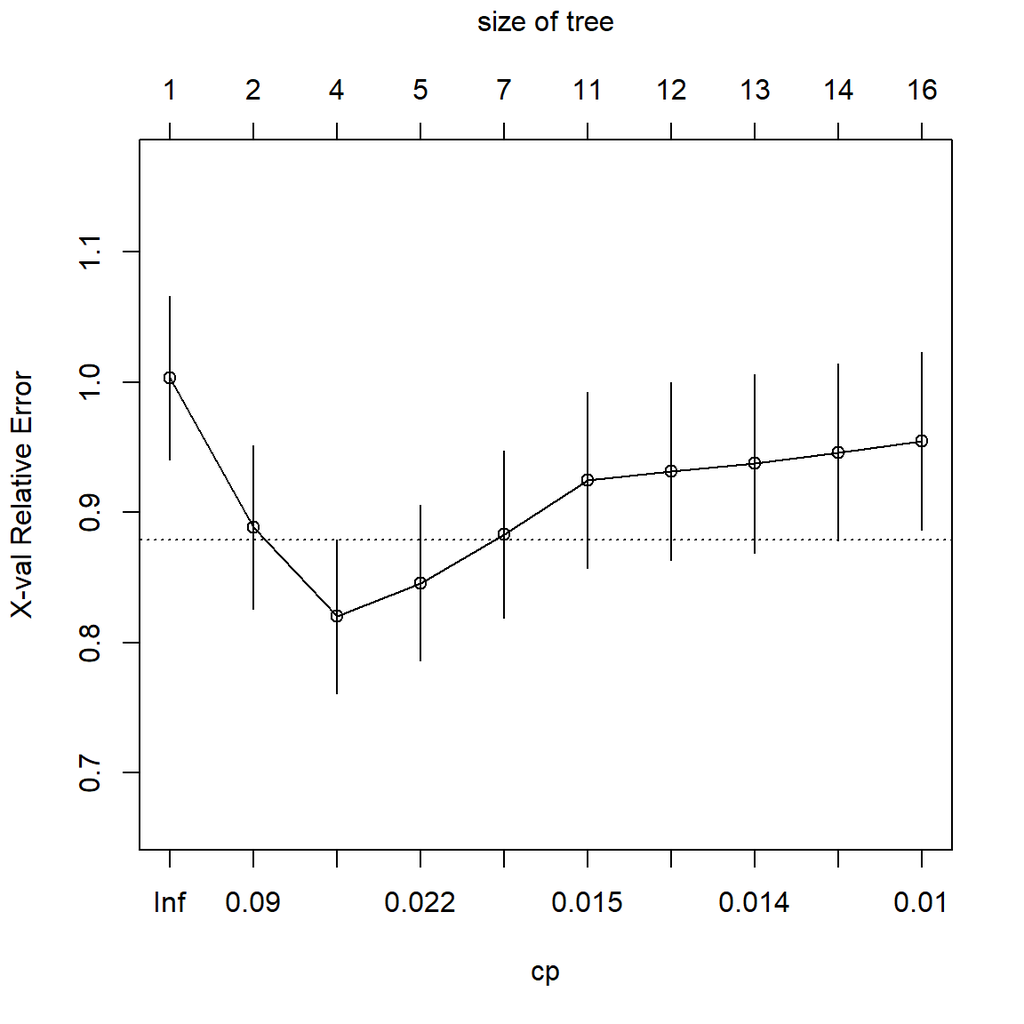

```r
plotcp(tree5)
```

```r
tree1.pred  <- predict(tree1, newdata = data.test)
tree2.pred  <- predict(tree2, newdata = data.test)
tree3.pred  <- predict(tree3, newdata = data.test)
tree4.pred  <- predict(tree3, newdata = data.test)
lm.pred <- predict(model.lm, data.test)
```

4 nodes is an optimal number for this regression tree.

The pruned tree has lowest mean square of prediction error and highest R2. However, all of the models are similar to simple linear model.

```r
 bind_cols(tibble(tree1.pred,
                  tree2.pred,
                  tree3.pred,
                  tree4.pred,
                  lm.pred)) %>%
  map_dfr(getRegressionMetrics, real = data.test$popularity, .id = "model")
```

```
##        model      MSE     RMSE      MAE    MedAE        R2
## 1 tree1.pred 38.19212 6.179977 4.674106 3.512821 0.1793061
## 2 tree2.pred 37.83439 6.150967 4.516469 3.142857 0.1869932
## 3 tree3.pred 37.63894 6.135059 4.647806 3.574586 0.1911931
## 4 tree4.pred 37.63894 6.135059 4.647806 3.574586 0.1911931
## 5    lm.pred 37.88282 6.154902 4.602702 3.734047 0.1859524
```

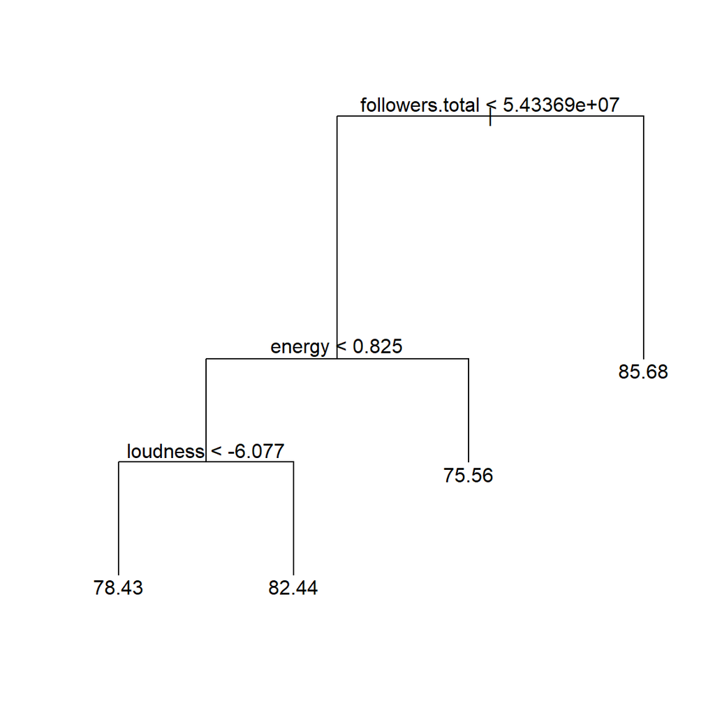

```r
tree.final <- tree4
tree.final.pred <- tree4.pred
plot(tree.final); text(tree.final, pretty = 0)
```